# LuthraSauravPS3

Saurav Luthra

2025-02-28

# SAURAV LUTHRA, MTH643 PROBLEM SET 3

## =========== OVERVIEW ===========

**HP :** Helmerich & Payne, Inc. (NYSE)

**PDS :** Precision Drilling Corporation (NYSE)

## =========== SETUP ===========

Getting the following for HP and PDS:

- prices
- returns
- log-returns
- sorted log-returns

```r
# ==============================================================================
# SETUP AND GET DATA FOR HP

getSymbols("HP", src = "yahoo", from = as.Date("2020-02-01", to = as.Date("2025-02-01")))
```

```
## [1] "HP"
```

```r
HP_prices <- (HP$HP.Adjusted)

HP_log_returns <- as.vector(diff(log(HP_prices))[-1])
HP_log_returns2 <- copy(HP_log_returns)
HP_log_returns_sorted <- sort(HP_log_returns)

HP_n <- length(HP_log_returns_sorted)

# ==============================================================================
# SETUP AND GET DATA FOR PDS

getSymbols("PDS", src = "yahoo", from = as.Date("2020-02-01", to = as.Date("2025-02-01")))
```

```
## [1] "PDS"
```

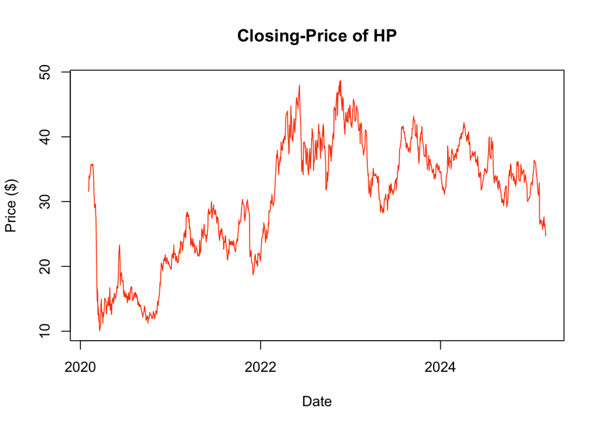

```r
PDS_prices <- (PDS$PDS.Adjusted)

PDS_log_returns <- as.vector(diff(log(PDS_prices))[-1])
PDS_log_returns2 <- copy(PDS_log_returns)
PDS_log_returns_sorted <- sort(PDS_log_returns)

PDS_n <- length(PDS_log_returns_sorted)

# ==============================================================================
# PLOT PRICES, LOG-RETURNS, AND SORTED LOG-RETURNS FOR HP

# plot HP price series
plot(index(HP_prices), HP_prices, type = "l", col = "orangered", lwd = 1, main = "Closing-Price of HP", xlab = "Date", ylab = "Price ($)")
```

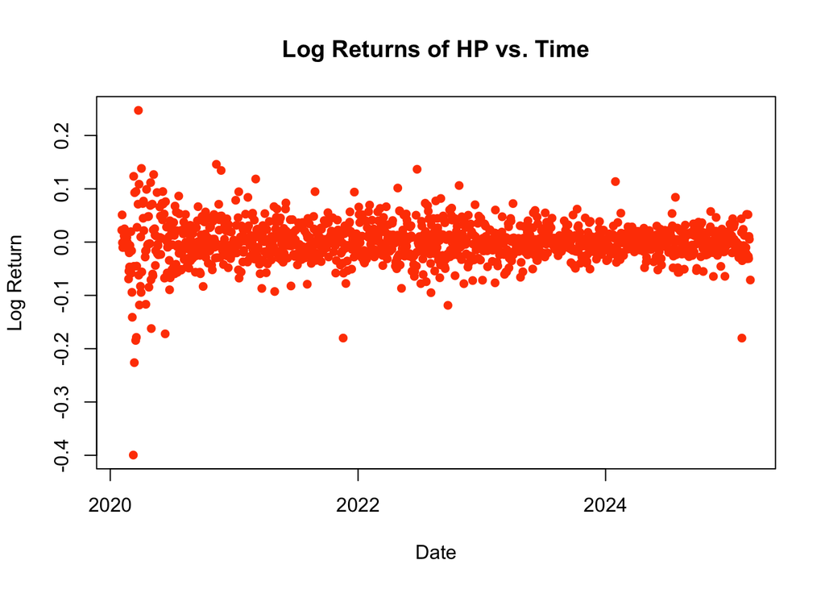

```r
# plot HP log returns
plot(index(HP_prices)[-1], HP_log_returns, type = "p", col = "orangered", pch = 16, main = "Log Returns of HP vs. Time", xlab = "Date", ylab = "Log Return")
```

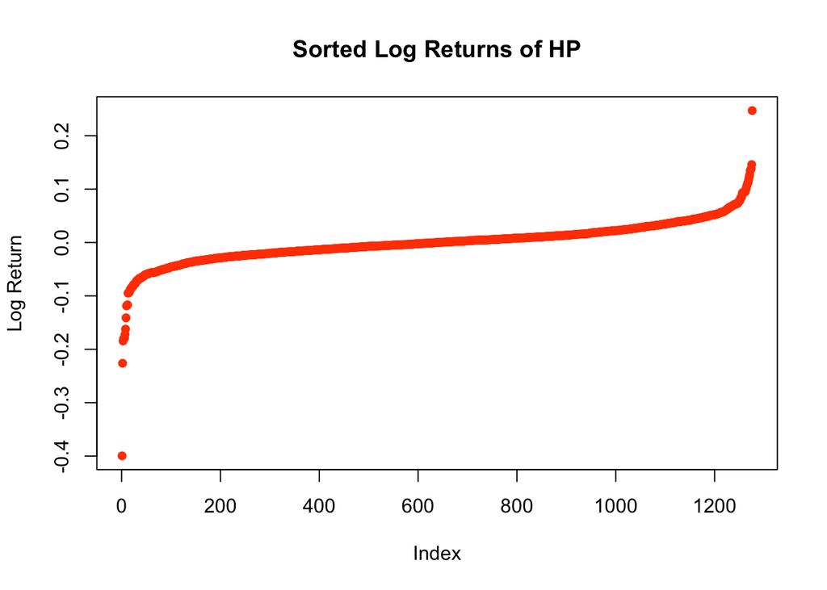

```r
# plot HP sorted log returns
plot(1:length(HP_log_returns_sorted), HP_log_returns_sorted, type="p", col="orangered", pch=16, main="Sorted Log Returns of HP", xlab="Index", ylab="Log Return")
```

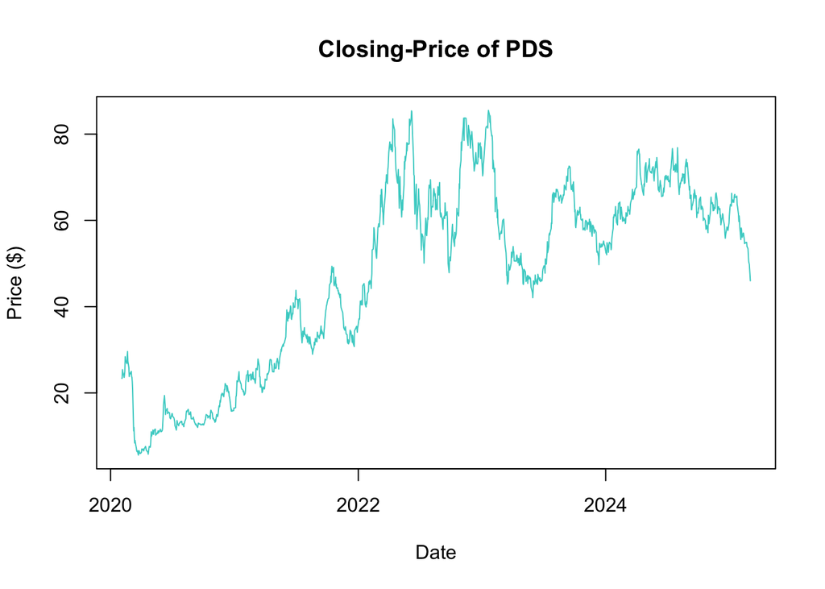

```r
# ==============================================================================
# PLOT PRICES, LOG-RETURNS, AND SORTED LOG-RETURNS FOR PDS

# plot PDS price series
plot(index(PDS_prices), PDS_prices, type = "l", col = "mediumturquoise", lwd = 1, main = "Closing-Price of PDS", xlab = "Date", ylab = "Price ($)")
```

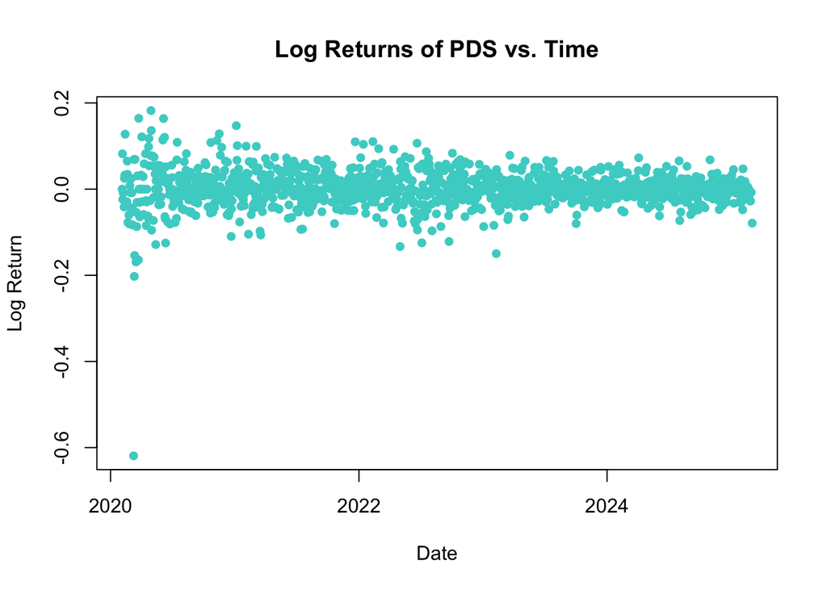

```r
# plot PDS log returns
plot(index(PDS_prices)[-1], PDS_log_returns, type = "p", col = "mediumturquoise", pch = 16, main = "Log Returns of PDS vs. Time", xlab = "Date", ylab = "Log Return")
```

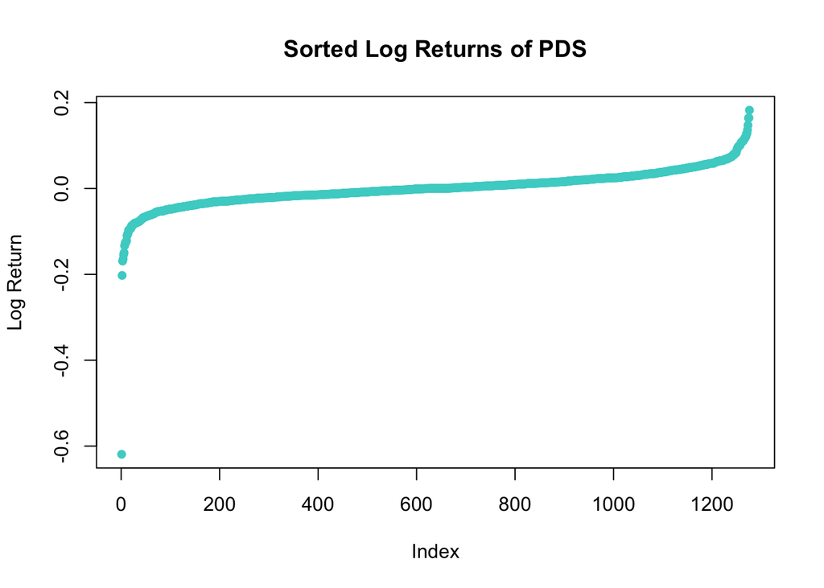

```r
# plot PDS sorted log returns
plot(1:length(PDS_log_returns_sorted), PDS_log_returns_sorted, type="p", col = "mediumturquoise", pch = 16, main = "Sorted Log Returns of PDS", xlab="Index", ylab="Log Return")
```

## =========== QUESTION 1 ===========

#### [**Kernel Density Estimate and Parametric (Normal, Student-T) Estimate of Log-Return Density**]

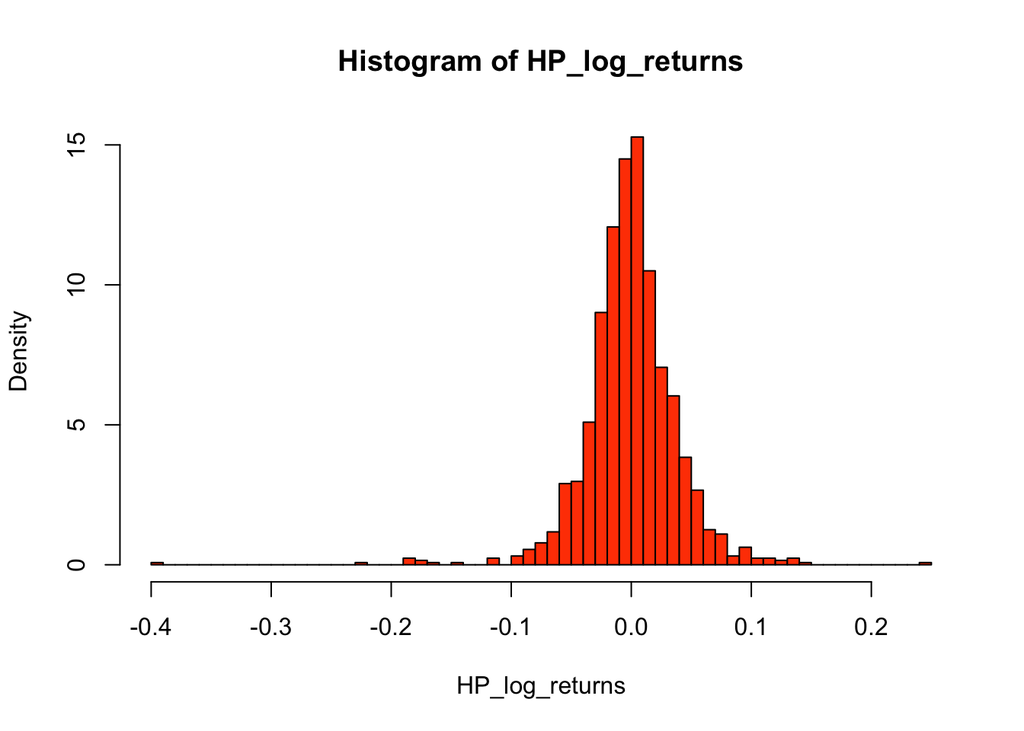

```r
# ==============================================================================
# SETUP FOR ANALYZING HP LOG-RETURNS

HP_max   <- max(HP_log_returns)
HP_min   <- min(HP_log_returns)
HP_n     <- length(HP_log_returns)

HP_mu    <- mean(HP_log_returns)
HP_sigma <- sd(HP_log_returns)
HP_iqr   <- IQR(HP_log_returns)
HP_bw    <- 0.9 * min(HP_sigma, HP_iqr / 1.34) * HP_n^(-1/5)

# ==============================================================================
# HISTOGRAM OF HP LOG-RETURNS

hist(HP_log_returns, breaks=50,  freq=FALSE,col='orangered')
```

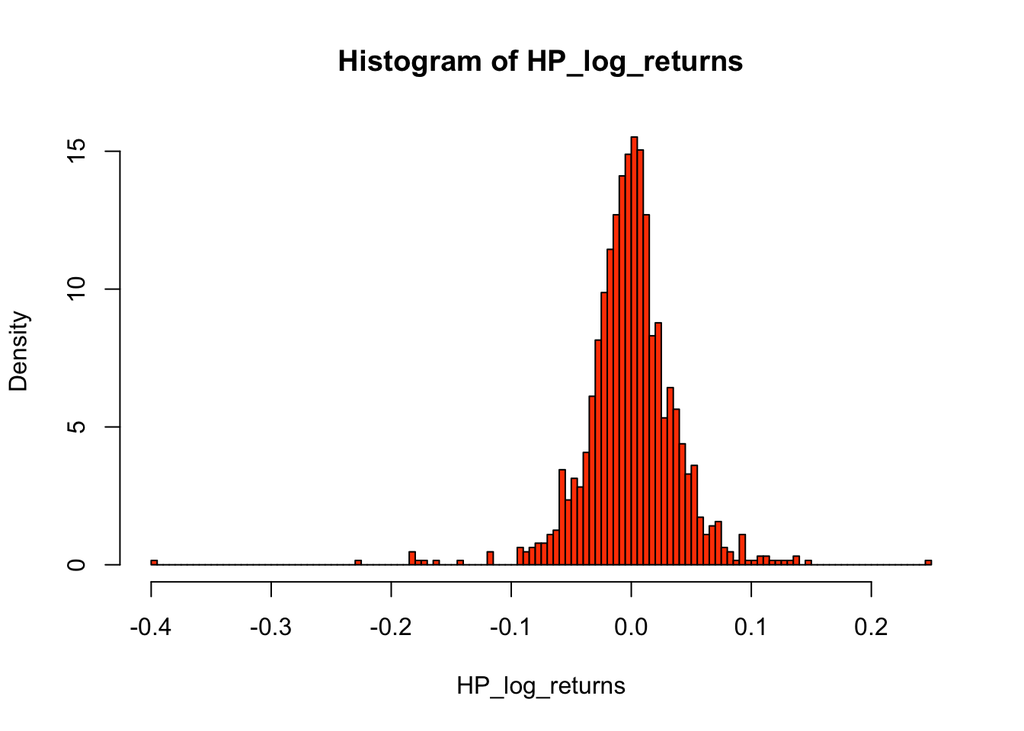

```r
hist(HP_log_returns, breaks=100, freq=FALSE,col='orangered')
```

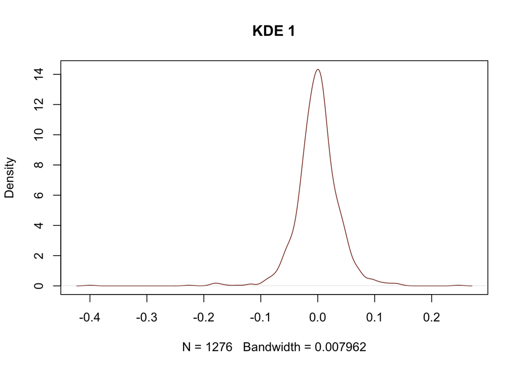

```r
# ==============================================================================
# KERNEL DENSITY ESTIMATE (KDE) OF HP LOG-RETURNS

plot(density(HP_log_returns, bw = HP_bw + 0.002), col='coral4', main="KDE 1", lwd=1)
```

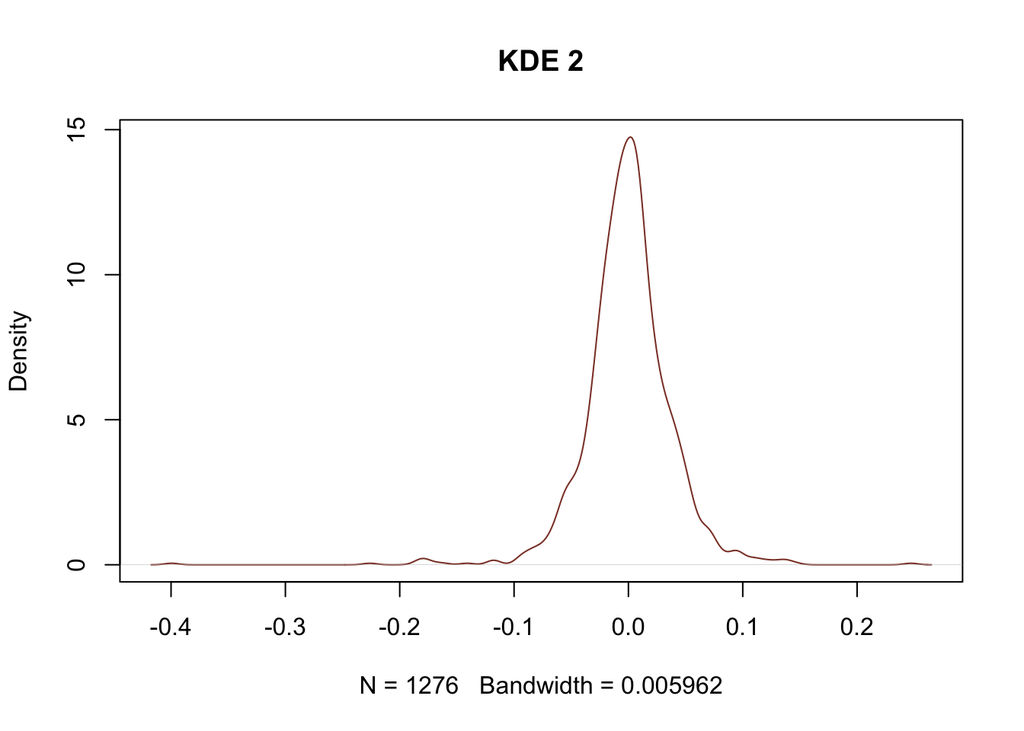

```r
plot(density(HP_log_returns, bw = HP_bw        ), col='coral4', main="KDE 2", lwd=1)
```

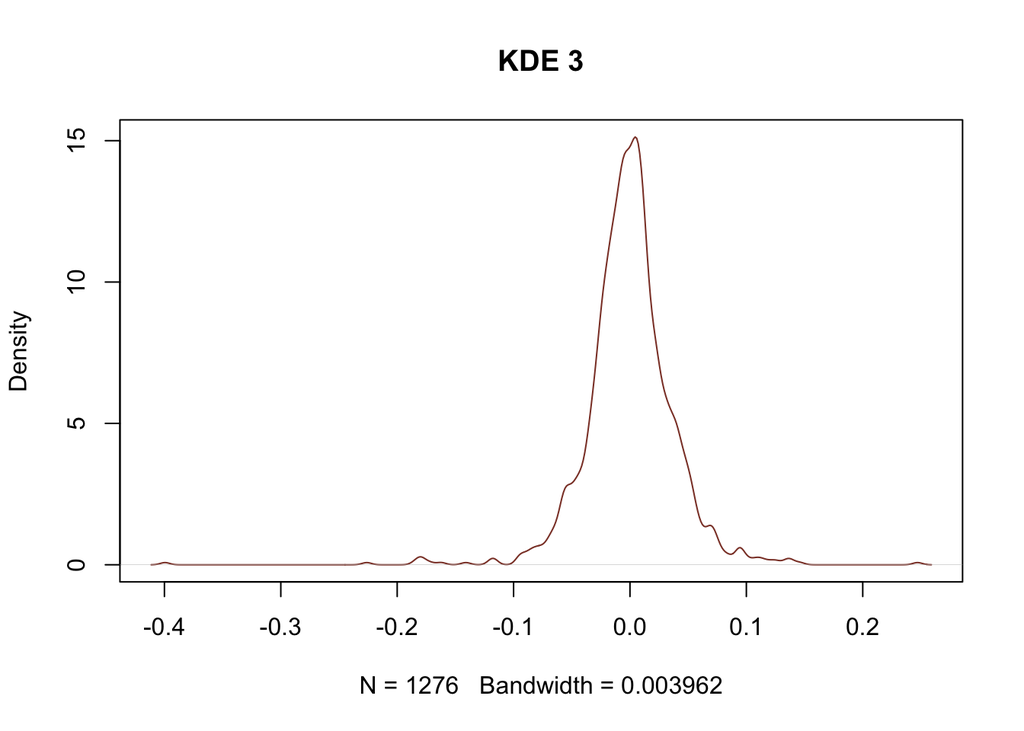

```r
plot(density(HP_log_returns, bw = HP_bw - 0.002), col='coral4', main="KDE 3", lwd=1)
```

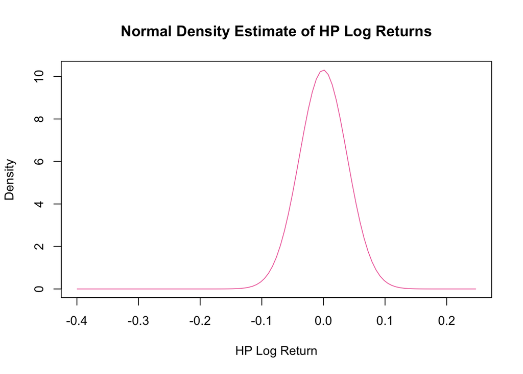

```r
HP_kde <- density(HP_log_returns, bw = HP_bw)

# ==============================================================================
# NORMAL DENSITY ESTIMATE OF HP LOG-RETURNS

HP_norm <- function(x) dnorm(x, mean=HP_mu, sd=HP_sigma)

curve(HP_norm, from=HP_min, to=HP_max, col="hotpink2", lwd=1, main="Normal Density Estimate of HP Log Returns", xlab='HP Log Return', ylab='Density')
```

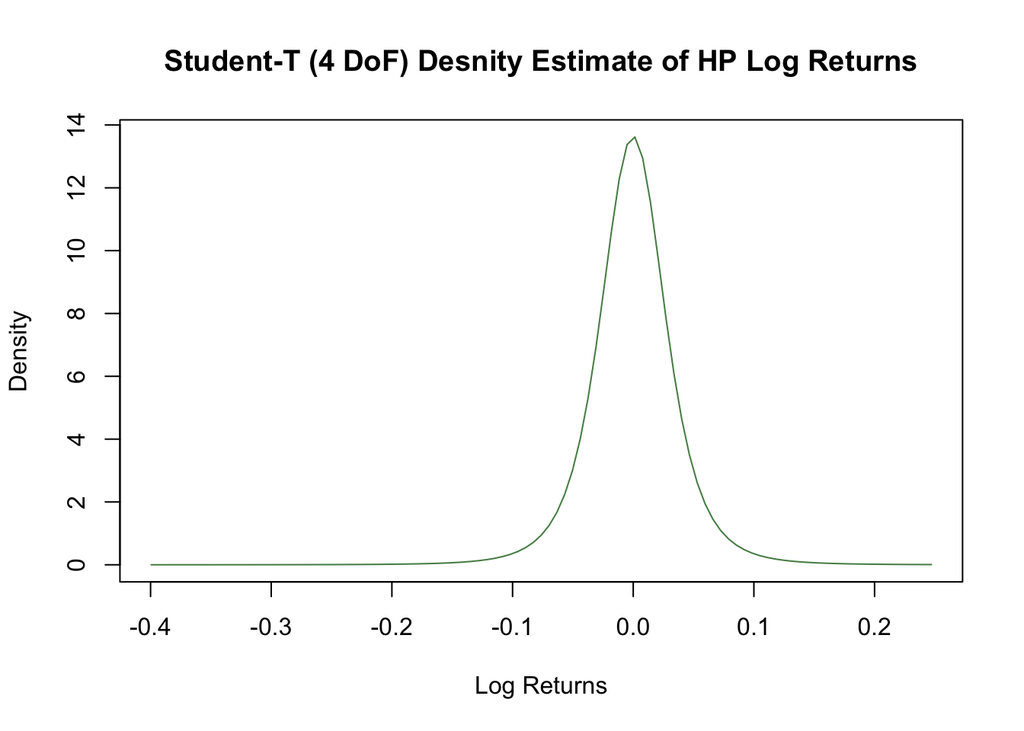

```r
# ==============================================================================
# STUDENT-T DENSITY ESTIMATE OF HP LOG-RETURNS

# median absolute deviation (MAD) of HP log returns
HP_mad <- mad(HP_log_returns)

HP_dof = 4

# define the T-distribution density function
HP_t <- function(x) dt((x - HP_mu) / HP_mad, df=HP_dof) / HP_mad

curve(HP_t, col='palegreen4', from=HP_min, to=HP_max, main="Student-T (4 DoF) Desnity Estimate of HP Log Returns", xlab='Log Returns', ylab='Density')
```

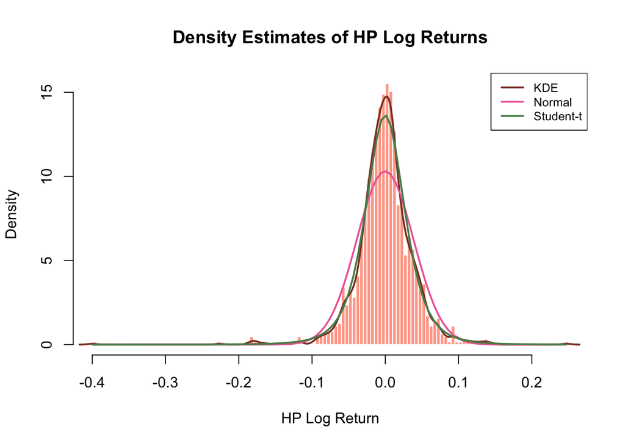

```r
# ==============================================================================
# FINAL PLOT: OVERLAY HISTOGRAM, KDE, NORMAL, AND STUDENT-T DENSITY ESTIMATES

# Create histogram and set freq=FALSE for density scale
hist(HP_log_returns, breaks=100, freq=FALSE, col=rgb(1, 0.27, 0, 0.5), border="white",
     main="Density Estimates of HP Log Returns", xlab="HP Log Return", ylab="Density")

# Overlay KDE density estimate
lines(HP_kde, col="coral4", lwd=2)

# Overlay Normal density estimate
curve(HP_norm, from=HP_min, to=HP_max, col="hotpink2", lwd=2, add=TRUE)

# Overlay Student-t density estimate
curve(HP_t, from=HP_min, to=HP_max, col="palegreen4", lwd=2, add=TRUE)

# Add a legend
legend("topright", legend=c("KDE", "Normal", "Student-t"),
       col=c("coral4", "hotpink2", "palegreen4"), lwd=2, cex=0.8)
```

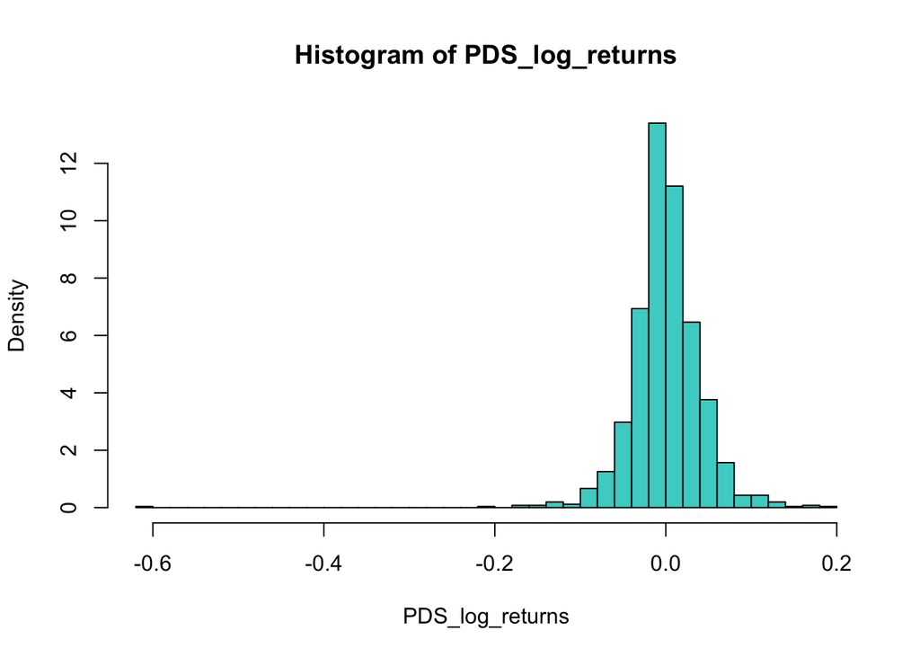

```r
# ==============================================================================
# SETUP FOR ANALYZING PDS LOG-RETURNS

PDS_max   <- max(PDS_log_returns)
PDS_min   <- min(PDS_log_returns)
PDS_n     <- length(PDS_log_returns)

PDS_mu    <- mean(PDS_log_returns)
PDS_sigma <- sd(PDS_log_returns)
PDS_iqr   <- IQR(PDS_log_returns)
PDS_bw    <- 0.9 * min(PDS_sigma, PDS_iqr / 1.34) * PDS_n^(-1/5)

# ==============================================================================
# HISTOGRAM OF PDS LOG-RETURNS

hist(PDS_log_returns, breaks=50,  freq=FALSE,col='mediumturquoise')
```

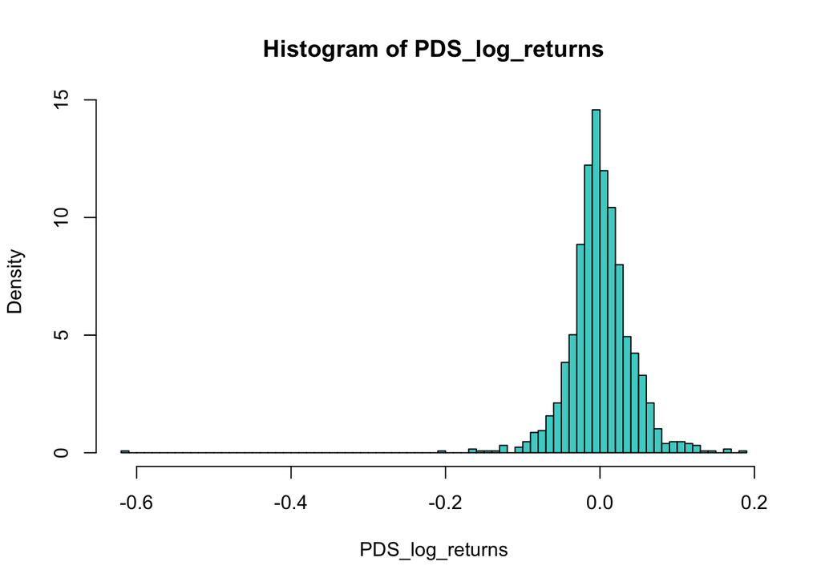

```r
hist(PDS_log_returns, breaks=100, freq=FALSE,col='mediumturquoise')
```

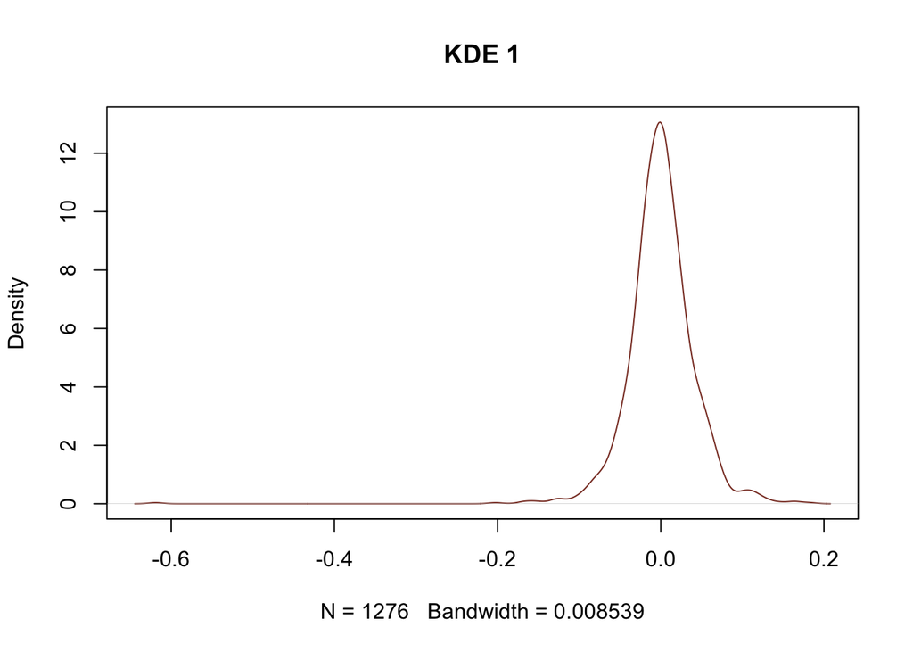

```r
# ==============================================================================
# KERNEL DENSITY ESTIMATE (KDE) OF PDS LOG-RETURNS

plot(density(PDS_log_returns, bw = PDS_bw + 0.002), col='coral4', main="KDE 1", lwd=1)
```

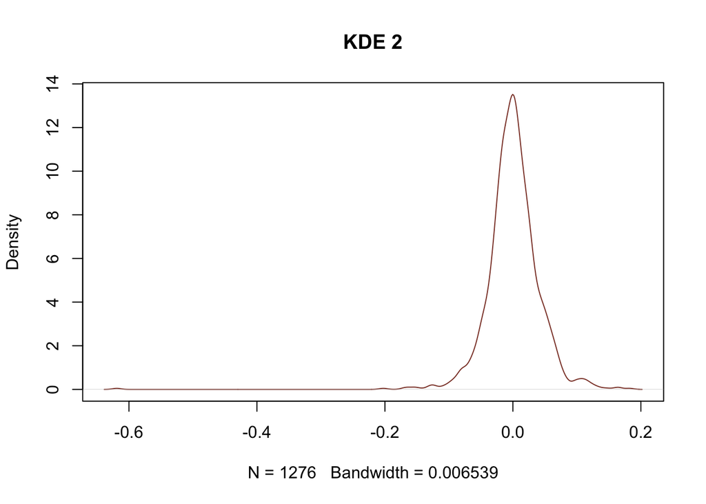

```r
plot(density(PDS_log_returns, bw = PDS_bw        ), col='coral4', main="KDE 2", lwd=1)
```

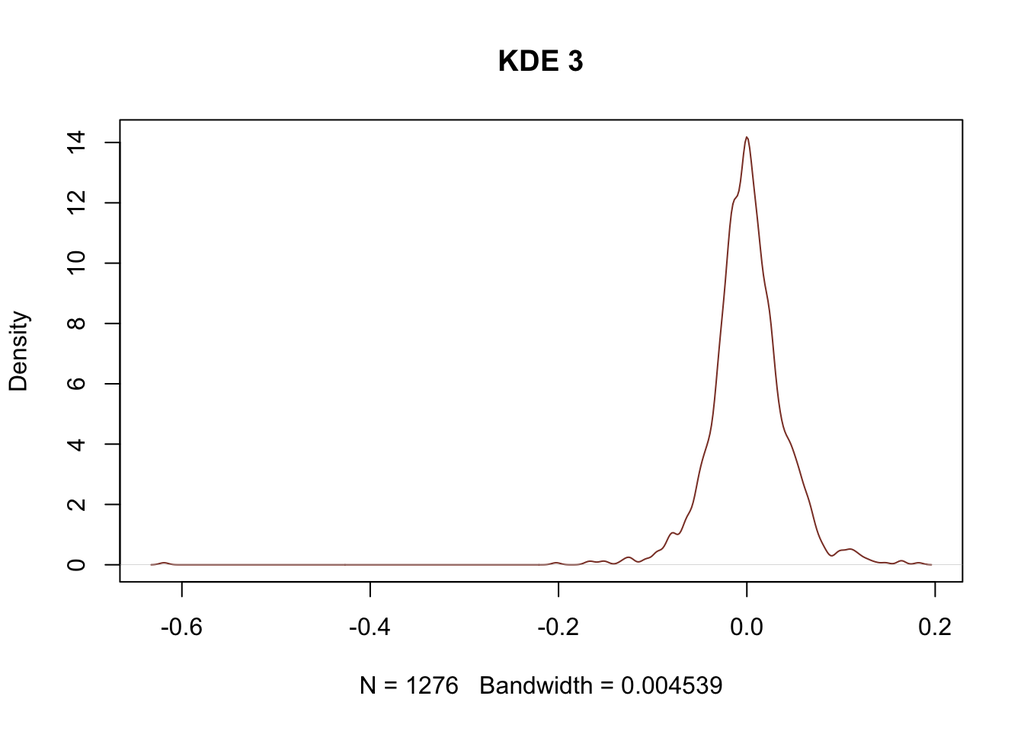

```r
plot(density(PDS_log_returns, bw = PDS_bw - 0.002), col='coral4', main="KDE 3", lwd=1)
```

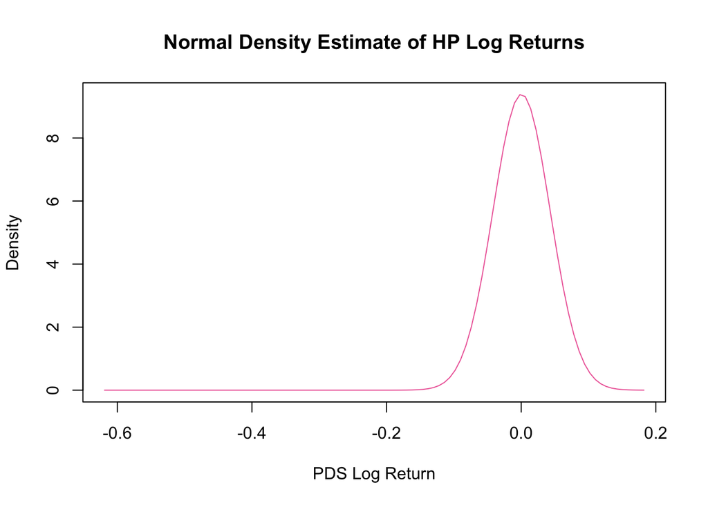

```r
PDS_kde <- density(PDS_log_returns, bw = PDS_bw)

# ==============================================================================
# NORMAL DENSITY ESTIMATE OF PDS LOG-RETURNS

PDS_norm <- function(x) dnorm(x, mean=PDS_mu, sd=PDS_sigma)

curve(PDS_norm, from=PDS_min, to=PDS_max, col="hotpink2", lwd=1, main="Normal Density Estimate of HP Log Returns", xlab='PDS Log Return', ylab='Density')
```

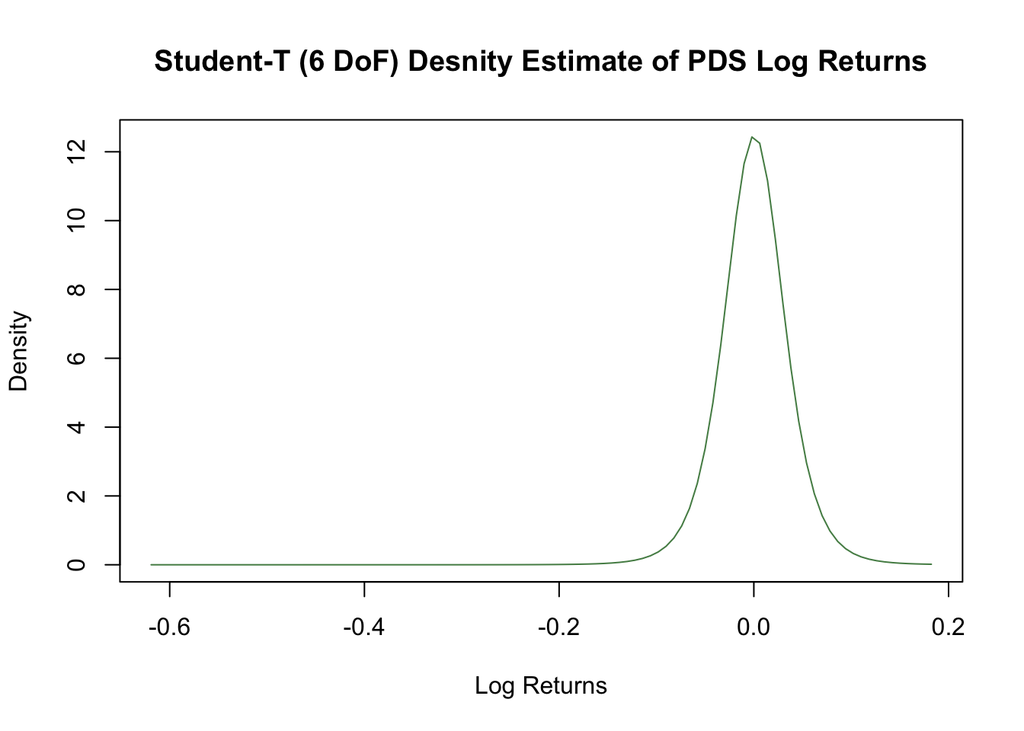

```r
# ==============================================================================
# STUDENT-T DENSITY ESTIMATE OF PDS LOG-RETURNS

# median absolute deviation (MAD) of HP log returns
PDS_mad <- mad(PDS_log_returns)

PDS_dof = 6

# define the T-distribution density function
PDS_t <- function(x) dt((x - PDS_mu) / PDS_mad, df=PDS_dof) / PDS_mad

curve(PDS_t, col='palegreen4', from=PDS_min, to=PDS_max, main="Student-T (6 DoF) Desnity Estimate of PDS Log Returns", xlab='Log Returns', ylab='Density')
```

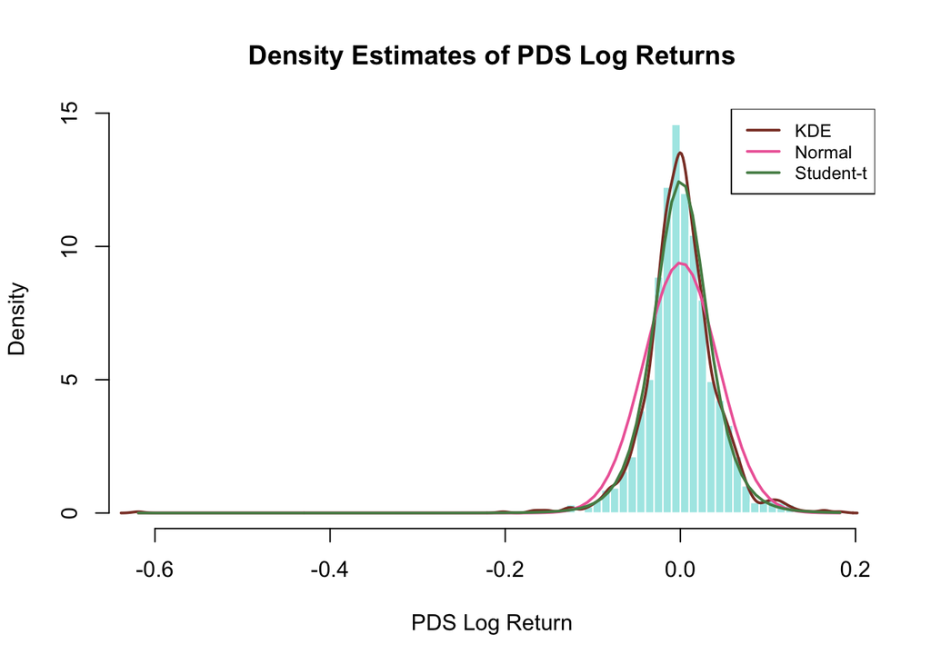

```r
# ==============================================================================
# FINAL PLOT: OVERLAY HISTOGRAM, KDE, NORMAL, AND STUDENT-T DENSITY ESTIMATES

# Create histogram and set freq=FALSE for density scale
hist(PDS_log_returns, breaks=100, freq=FALSE, col=rgb(0.28, 0.82, 0.8, 0.5), border="white",
     main="Density Estimates of PDS Log Returns", xlab="PDS Log Return", ylab="Density")

# Overlay KDE density estimate
lines(PDS_kde, col="coral4", lwd=2)

# Overlay Normal density estimate
curve(PDS_norm, from=PDS_min, to=PDS_max, col="hotpink2", lwd=2, add=TRUE)

# Overlay Student-t density estimate
curve(PDS_t, from=PDS_min, to=PDS_max, col="palegreen4", lwd=2, add=TRUE)

# Add a legend
legend("topright", legend=c("KDE", "Normal", "Student-t"),
       col=c("coral4", "hotpink2", "palegreen4"), lwd=2, cex=0.8)
```

## =========== QUESTION 2 ===========

#### [**Logistic Regression to Predict Up/Down Moves in Log Returns**]

The first logistic regression model, based on the PDS log returns, demonstrates a predictive accuracy of 52%, which indicates only a marginal ability to correctly predict the direction of the next log return. However, none of the predictor variables—lag1, lag2, and volume—are statistically significant, as evidenced by their p-values being greater than the conventional significance threshold of 0.05. This suggests that these variables do not exhibit a strong relationship with the target variable, direction, in the context of this model.

Similarly, the second logistic regression model, which utilizes the HP log returns, yields an accuracy of 48.8%, further highlighting the modest predictive capability of the model. Again, none of the predictor variables—lag1, lag2, and volume—are found to be statistically significant, as their p-values exceed the threshold for significance. This further reinforces the observation that the selected predictors do not appear to have a meaningful influence on the direction of the log returns.

Both models exhibit similar residual deviance and AIC values, suggesting comparable goodness-of-fit between the two models. Despite this, the low accuracy and the absence of statistically significant relationships indicate that the chosen lagged log returns and volume may not be the most effective predictors for forecasting the direction of log returns in these particular cases. Further refinement of the model, potentially incorporating additional predictors or alternative methodologies, may be necessary to improve predictive performance.

```r
# define direction: 1 if log return > 0, otherwise 0
HP_direction <- ifelse(HP_log_returns > 0, 1, 0)

# create volume predictor
HP_volume <- as.vector(HP$HP.Volume)[-1]
HP_volume <- c(NA, HP_volume[-length(HP_volume)])

# create lagged log-return predictors
HP_lag1 <- c(NA, HP_log_returns[-length(HP_log_returns)])
HP_lag2 <- c(NA, NA, HP_log_returns <- HP_log_returns[-c((length(HP_log_returns)-1), length(HP_log_returns))])

cat("Length of direction: ", length(HP_direction), "\n")
```

```
## Length of direction:  1276
```

```r
cat("Length of vol.     : ", length(HP_volume), "\n")
```

```
## Length of vol.     :  1276
```

```r
cat("Length of lag1     : ", length(HP_lag1), "\n")
```

```
## Length of lag1     :  1276
```

```r
cat("Length of lag2     : ", length(HP_lag2), "\n")
```

```
## Length of lag2     :  1276
```

```r
# create data frame and remove first two rows (NA values from lagged variables)
HP_data <- data.frame(HP_direction, HP_lag1, HP_lag2, HP_volume)

# remove rows with NA values
HP_data <- na.omit(HP_data)

HP_data
```

[output not shown]

[output cut: 1260 more lines]

```r
#create logisitic regression model
HP_lr <- glm(HP_direction ~ HP_lag1 + HP_lag2 + HP_volume, data = HP_data, family = binomial)
summary(HP_lr)
```

```
##
## Call:
## glm(formula = HP_direction ~ HP_lag1 + HP_lag2 + HP_volume, family = binomial,
##     data = HP_data)
##
## Coefficients:
##               Estimate Std. Error z value Pr(>|z|)
## (Intercept)  9.409e-02  9.538e-02   0.986    0.324
## HP_lag1     -1.761e+00  1.464e+00  -1.202    0.229
## HP_lag2     -6.685e-01  1.456e+00  -0.459    0.646
## HP_volume   -7.120e-08  5.031e-08  -1.415    0.157
##
## (Dispersion parameter for binomial family taken to be 1)
##
##     Null deviance: 1766.1  on 1273  degrees of freedom
## Residual deviance: 1762.3  on 1270  degrees of freedom
## AIC: 1770.3
##
## Number of Fisher Scoring iterations: 3
```

```r
# get predicted probabilities
HP_lr_pred_prob <- predict(HP_lr, type = "response")

# convert probabilities to binary predictions
HP_lr_pred_dir <- ifelse(HP_lr_pred_prob > 0.5, 1, 0)

# compute and display confusion matrix
HP_lr_conf_matrix <- table(Predicted = HP_lr_pred_dir, Actual = HP_data$HP_direction)
HP_lr_conf_matrix
```

```
##          Actual
## Predicted   0   1
##         0 307 317
##         1 335 315
```

```r
# calculate accuracy
HP_lr_accuracy <- mean(HP_lr_pred_dir == HP_data$HP_direction)
print(paste("HP LR Model Accuracy:", round(HP_lr_accuracy, 3)))
```

```
## [1] "HP LR Model Accuracy: 0.488"
```

```r
# define direction: 1 if log return > 0, otherwise 0
PDS_direction <- ifelse(PDS_log_returns > 0, 1, 0)

# create volume predictor
PDS_volume <- as.vector(PDS$PDS.Volume)[-1]
PDS_volume <- c(NA, PDS_volume[-length(PDS_volume)])

# create lagged log-return predictors
PDS_lag1 <- c(NA, PDS_log_returns[-length(PDS_log_returns)])
PDS_lag2 <- c(NA, NA, HP_log_returns <- PDS_log_returns[-c((length(PDS_log_returns)-1), length(PDS_log_returns))])

cat("Length of direction: ", length(PDS_direction), "\n")
```

```
## Length of direction:  1276
```

```r
cat("Length of vol.     : ", length(PDS_volume), "\n")
```

```
## Length of vol.     :  1276
```

```r
cat("Length of lag1     : ", length(PDS_lag1), "\n")
```

```
## Length of lag1     :  1276
```

```r
cat("Length of lag2     : ", length(PDS_lag2), "\n")
```

```
## Length of lag2     :  1276
```

```r
# create data frame and remove first two rows (NA values from lagged variables)
PDS_data <- data.frame(PDS_direction, PDS_lag1, PDS_lag2, PDS_volume)

# remove rows with NA values
PDS_data <- na.omit(PDS_data)

PDS_data
```

[output not shown]

[output cut: 1260 more lines]

```r
#create logisitic regression model
PDS_lr <- glm(PDS_direction ~ PDS_lag1 + PDS_lag2 + PDS_volume, data = PDS_data, family = binomial)
summary(PDS_lr)
```

```
##
## Call:
## glm(formula = PDS_direction ~ PDS_lag1 + PDS_lag2 + PDS_volume,
##     family = binomial, data = PDS_data)
##
## Coefficients:
##               Estimate Std. Error z value Pr(>|z|)
## (Intercept) -5.486e-02  1.013e-01  -0.542    0.588
## PDS_lag1     4.606e-01  1.328e+00   0.347    0.729
## PDS_lag2    -7.788e-01  1.330e+00  -0.586    0.558
## PDS_volume  -1.108e-07  1.203e-06  -0.092    0.927
##
## (Dispersion parameter for binomial family taken to be 1)
##
##     Null deviance: 1764.9  on 1273  degrees of freedom
## Residual deviance: 1764.4  on 1270  degrees of freedom
## AIC: 1772.4
##
## Number of Fisher Scoring iterations: 3
```

```r
# get predicted probabilities
PDS_lr_pred_prob <- predict(PDS_lr, type = "response")

# convert probabilities to binary predictions
PDS_lr_pred_dir <- ifelse(PDS_lr_pred_prob > 0.5, 1, 0)

# compute and display confusion matrix
PDS_lr_conf_matrix <- table(Predicted = PDS_lr_pred_dir, Actual = PDS_data$PDS_direction)
PDS_lr_conf_matrix
```

```
##          Actual
## Predicted   0   1
##         0 640 594
##         1  17  23
```

```r
# calculate accuracy
PDS_lr_accuracy <- mean(PDS_lr_pred_dir == PDS_data$PDS_direction)
print(paste("PDS LR Model Accuracy:", round(PDS_lr_accuracy, 3)))
```

```
## [1] "PDS LR Model Accuracy: 0.52"
```

## =========== QUESTION 3 ===========

#### [**Linear Discriminant Analysis (LDA) Model of Direction of Log-Returns**]

```r
HP_lda <- lda(HP_direction ~ HP_lag1 + HP_lag2 + HP_volume, data = HP_data)
print(HP_lda)
```

```
## Call:
## lda(HP_direction ~ HP_lag1 + HP_lag2 + HP_volume, data = HP_data)
##
## Prior probabilities of groups:
##         0         1
## 0.5039246 0.4960754
##
## Group means:
##        HP_lag1       HP_lag2 HP_volume
## 0  0.001023908  0.0002955104   1610953
## 1 -0.001351963 -0.0005850933   1503370
##
## Coefficients of linear discriminants:
##                     LD1
## HP_lag1   -1.632625e+01
## HP_lag2   -6.182088e+00
## HP_volume -5.782990e-07
```

```r
HP_lda_pred_dir <- predict(HP_lda)

HP_lda_accuracy <- mean(HP_lda_pred_dir$class == HP_data$HP_direction)
print(paste("HP LDA Model Accuracy:", round(HP_lda_accuracy, 3)))
```

```
## [1] "HP LDA Model Accuracy: 0.488"
```

```r
PDS_lda <- lda(PDS_direction ~ PDS_lag1 + PDS_lag2 + PDS_volume, data = PDS_data)
print(PDS_lda)
```

```
## Call:
## lda(PDS_direction ~ PDS_lag1 + PDS_lag2 + PDS_volume, data = PDS_data)
##
## Prior probabilities of groups:
##         0         1
## 0.5156986 0.4843014
##
## Group means:
##       PDS_lag1      PDS_lag2 PDS_volume
## 0 0.0002311577  0.0012597622   70285.64
## 1 0.0009773203 -0.0001066129   70032.60
##
## Coefficients of linear discriminants:
##                      LD1
## PDS_lag1    1.213699e+01
## PDS_lag2   -2.051031e+01
## PDS_volume -2.923010e-06
```

```r
PDS_lda_pred_dir <- predict(PDS_lda)

PDS_lda_accuracy <- mean(HP_lda_pred_dir$class == PDS_data$PDS_direction)
print(paste("PDS LDA Model Accuracy:", round(PDS_lda_accuracy, 3)))
```

```
## [1] "PDS LDA Model Accuracy: 0.502"
```

## =========== QUESTION 4 ===========

The scatter plot below shows that the log returns of HP and PDS are quite correlated, and hence, seem to be generally following the blue y=x line. This means that on any given day, the log return of HP and PDS are likely to be 1:1 with some level of variance. There a small number of drastic outliers of huge negative and positive returns, however in those scenarios, HP and PDS generally still move equivalently. This has a lot to do with the fact that both these companies are in the same industry, same country, and have similar fundamental and financial characteristics.

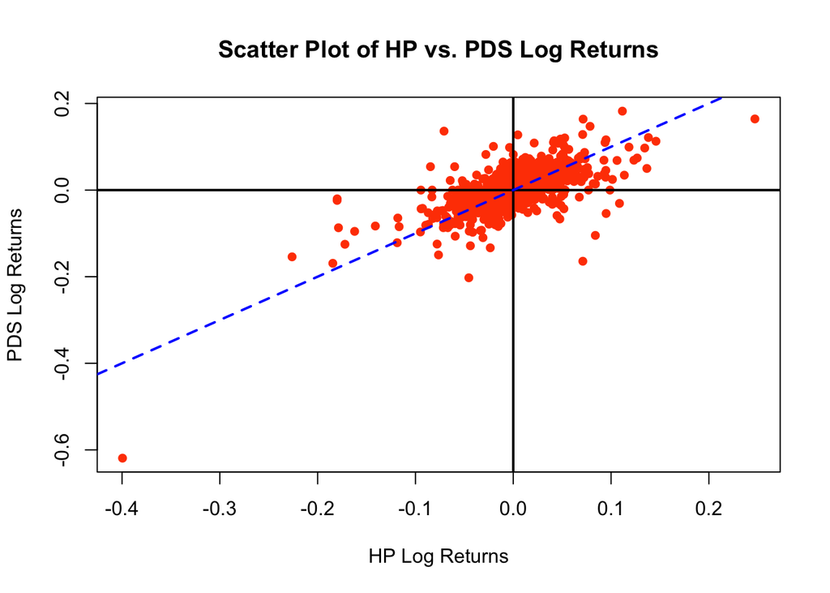

```r
plot(HP_log_returns2, PDS_log_returns2,
     main = "Scatter Plot of HP vs. PDS Log Returns",
     xlab = "HP Log Returns",
     ylab = "PDS Log Returns",
     col = "orangered",
     pch = 16)


# add vertical and horizontal lines at 0
abline(v = 0, col = "black", lty = 1, lwd = 2)
abline(h = 0, col = "black", lty = 1, lwd = 2)

# blue dashed line at y = x
abline(0, 1, col = "blue", lwd = 2, lty = 2)
```